# Solving problems using Analysis of Variance (ANOVA) in R

Eduardo Marquez Mora

2025

# One Way ANOVA: Heart Rates of Smokers

Researchers recorded resting heart rates (beats per minute) for three groups of adults: **nonsmokers, light smokers, and heavy smokers**. We wish to determine whether mean heart rate differs among the three groups.

```r
# -------------------------------
# Dataset
# -------------------------------

# Resting heart rate (bpm) by smoking category
nonSmoker = c(70, 58, 51, 56, 53, 53, 65)
lightSmoker = c(67, 75, 65, 78, 62, 70, 73)
heavySmoker = c(79, 80, 77, 77, 86, 68, 83)

# Response variable: Heart Rate
heartRate = c(nonSmoker, lightSmoker, heavySmoker)

# Categorical variable: People (with 7 observations each)
people = factor(rep(c("nonSmoker", "lightSmoker", "heavySmoker"), each = 7))

# Data frame for plotting and ANOVA
heartRateDataFrame = data.frame(people, heartRate)

# Display the first few rows of the data to verify structure
head(heartRateDataFrame)
```

```
##      people heartRate
## 1 nonSmoker        70
## 2 nonSmoker        58
## 3 nonSmoker        51
## 4 nonSmoker        56
## 5 nonSmoker        53
## 6 nonSmoker        53
```

### Generate the Descriptive Statistic of each group (non-smoker, light smoker, heavy smoker)

```r
# Extract data by group
nonSmoker = heartRateDataFrame$heartRate[heartRateDataFrame$people == "nonSmoker"]
lightSmoker = heartRateDataFrame$heartRate[heartRateDataFrame$people == "lightSmoker"]
heavySmoker = heartRateDataFrame$heartRate[heartRateDataFrame$people == "heavySmoker"]

# Statistics of each group
# nonSmokers
numOfNonSmokers = length(nonSmoker)
meanOfNonSmokers = mean(nonSmoker)
varianceOfNonSmokers = var(nonSmoker)
stdevOfNonSmokers = sd(nonSmoker)

# lightSmokers
numOfLightSmokers = length(lightSmoker)
meanOfLightSmokers = mean(lightSmoker)
varianceOfLightSmokers = var(lightSmoker)
stdevOfLightSmokers = sd(lightSmoker)

# heavySmokers
numOfHeavySmokers = length(heavySmoker)
meanOfHeavySmokers = mean(heavySmoker)
varianceOfHeavySmokers = var(heavySmoker)
stdevOfHeavySmokers = sd(heavySmoker)


# Summary Table
summaryTable = data.frame(
  Group = c("nonSmokers", "lightSmokers", "heavySmokers"),
  n = c(numOfNonSmokers, numOfLightSmokers, numOfHeavySmokers),
  Mean = round(c(meanOfNonSmokers, meanOfLightSmokers, meanOfHeavySmokers), 3),
  Variance = round(c(varianceOfNonSmokers, varianceOfLightSmokers, varianceOfHeavySmokers), 3),
  StdDev = round(c(stdevOfNonSmokers, stdevOfLightSmokers, stdevOfHeavySmokers), 3)
)

# Print the summary table
print(summaryTable)
```

```
##          Group n   Mean Variance StdDev
## 1   nonSmokers 7 58.000   49.333  7.024
## 2 lightSmokers 7 70.000   32.667  5.715
## 3 heavySmokers 7 78.571   32.286  5.682
```

**Key Insights:**

1. **Balanced Design:** Each group has *n = 7* samples, which is ideal for ANOVA.
2. **Highest Mean:** Heavy Smokers have the highest mean heart rate (78.571bpm)
3. **Lowest Mean:** Non Smokers have the lowest mean heart rate (58 bpm)
4. **Highest Variability:** Non Smokers also exhibit the greatest variability (Std. Dev. = 7.024).
5. **Lowest Variability:** Heavy Smokers has the most consistent results (Std. Dev. = 5.682).
6. **Initial Observation:** Clear differences in group means suggest a potential treatment effect to be tested with ANOVA.

### Generate ANOVA Table

```r
# Fit a one-way ANOVA model
# Response variable: heartRate
# Predictor (grouping factor): people
heartRateANOVA = aov(heartRate ~ people, data = heartRateDataFrame)

# Display the ANOVA table
# This output includes:
# - Degrees of Freedom (DF)
# - Sum of Squares (SS)
# - Mean Squares (MS)
# - F-statistic
# - P-value
summary(heartRateANOVA)
```

```
##             Df Sum Sq Mean Sq F value   Pr(>F)
## people       2 1494.9   747.4   19.62 3.01e-05 ***
## Residuals   18  685.7    38.1
## ---
## Signif. codes:  0 '***' 0.001 '**' 0.01 '*' 0.05 '.' 0.1 ' ' 1
```

**Interpretation**

- **Degrees of Freedom (Df):**
  - Between Groups (People): 2
  - Within Groups (Residuals): 18
- **Sum of Squares (SS):**
  - Between Groups(People): 1494.9
  - Within Groups(Residuals): 685.7
- **Mean Squares (MS):**
  - Between Groups (People): 747.4
  - Within Groups(Residuals): 38.1
- **F-value:** 19.62
- **P-value:** 0.0000301

> **Interpretation of p-value:**  
> Assuming the null hypothesis is true (that all three groups of people have the same mean heart rate)  
> Ho = HnonSmoker = HlightSmoker = HheavySmoker  
> Ha = At least one of the means differ

Since the p-value (0.0000301) is **less than 0.05**, we reject the null hypothesis and conclude that **at least one group of people has a significantly different mean heart rate**.

**Continued:**  
To determine *which specific pairs of mean heart rates* differ, a **Tukey HSD post-hoc test** will be performed.

### Boxplot to Confirm ANOVA Results

Before performing the Tukey HSD post-hoc test, we first create a boxplot to **visually confirm** the ANOVA results.  
The boxplot shows the distribution of mean heart rate for each group of people, helping us see differences in medians, variability, and potential outliers.

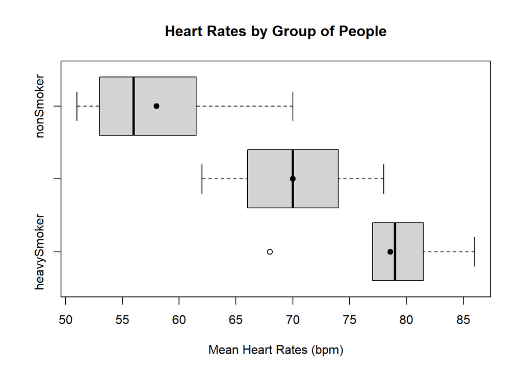

```r
# Create a horizontal boxplot to compare shear bond strength across the four repair kits
boxplot(heartRate ~ people,
        data = heartRateDataFrame,           # Data frame containing the variables
        horizontal = TRUE,               # Display boxes horizontally for better readability
        xlab = "Mean Heart Rates (bpm)",  # Label for the x-axis
        ylab = "",                        # Leave y-axis label blank since kit names are already shown
        main = "Heart Rates by Group of People") # Main title of the plot

# Add points to represent the group means on top of each box
points(tapply(heartRateDataFrame$heartRate, heartRateDataFrame$people, mean), # Compute mean for each group of people
       1:length(levels(heartRateDataFrame$people)),  # Match the position of each mean to the box location
       pch = 19)                               # Solid circles (pch = 19) for visibility
```

### Interpretation of the Boxplot

#### Visual Comparison

- Heavy Smokers have the highest mean heart rate
- The gap between these groups suggests a strong likelihood of significant differences.

### Summary

The boxplot results **support the ANOVA findings** that at least one group mean differs.  
However, while the boxplot suggests where differences may exist, a statistical test such as **Tukey’s HSD** is required to confirm which specific pairs of groups differ.

### Checking Normality with a Q-Q Plot

The Q-Q (quantile-quantile) plot is used to visually assess whether the residuals from the ANOVA model are approximately normally distributed.  
If the residuals are normal, the points should closely follow the diagonal reference line.

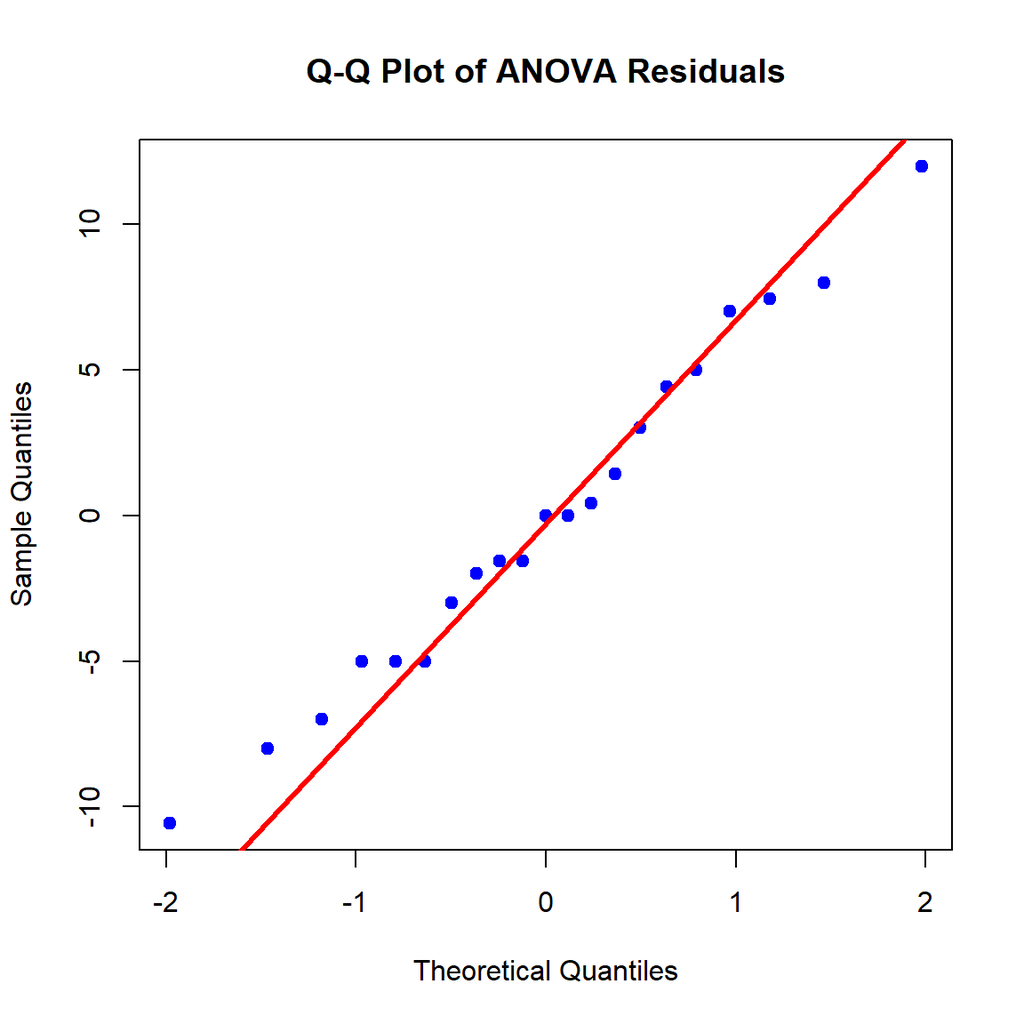

```r
# Extract residuals from the ANOVA model
residualsANOVA = residuals(heartRateANOVA)

# Create a Q-Q plot
qqnorm(residualsANOVA,
       main = "Q-Q Plot of ANOVA Residuals",
       xlab = "Theoretical Quantiles",
       ylab = "Sample Quantiles",
       pch = 19, col = "blue")

# Reference line
qqline(residualsANOVA, col = "red", lwd = 3)
```

#### Interpretation of Q-Q Plot

- Most points closely follow the red diagonal line, which represents a perfect normal distribution.
- A few points slightly deviate at the extremes (tails), but these deviations are minor and expected in small samples.

**Interpretation:**  
This indicates that the residuals are approximately normal, satisfying the normality assumption.

### Tukey’s HSD Test

```r
tukeyResult = TukeyHSD(heartRateANOVA) # Run Tukey's HSD post-hoc test


print(tukeyResult) # Print the Tukey test results
```

```
##   Tukey multiple comparisons of means
##     95% family-wise confidence level
##
## Fit: aov(formula = heartRate ~ people, data = heartRateDataFrame)
##
## $people
##                               diff       lwr         upr     p adj
## lightSmoker-heavySmoker  -8.571429 -16.99138  -0.1514738 0.0456328
## nonSmoker-heavySmoker   -20.571429 -28.99138 -12.1514738 0.0000200
## nonSmoker-lightSmoker   -12.000000 -20.41995  -3.5800453 0.0050912
```

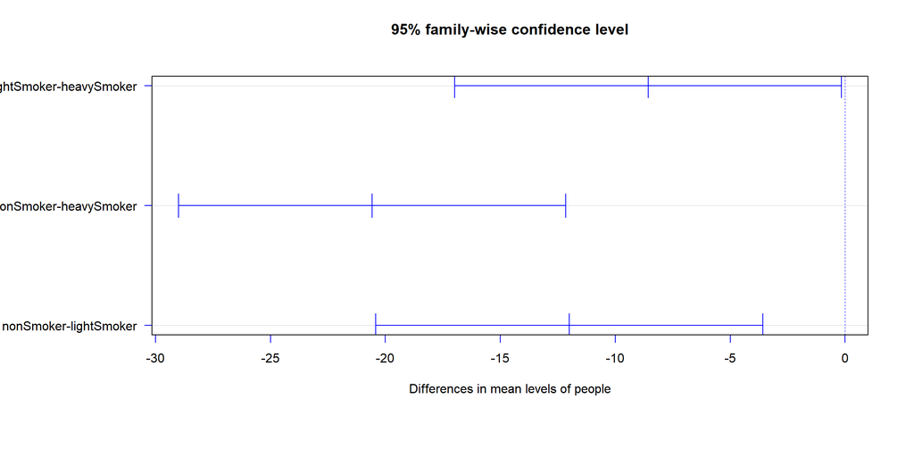

```r
#  Visualize Tukey HSD results
par(mar = c(8, 10, 5, 3)) # Increase left margin space

plot(tukeyResult, las = 1, col = "blue")  # Extra space for labels
```

### Interpretation of Tukey Results

#### Significant Differences

- **NonSmoker vs HeavySmoker**: `p = 0.0000200` → Significant difference, heavy smoker is higher
- **NonSmoker vs LightSmoker**: `p = 0.0050912` → Significant difference, light smoker is higher.
- **LightSmoker vs HeavySmoker**: `p = 0.045` → Significant difference, heavy smoker is slightly higher

### Conclusion

- Light Smokers and Heavy Smokers have **high mean heart rate**.
- There is a **significant difference** between the mean heart rates of non smokers and heavy smokers.
- These findings guide recommendations for the health related issues from people who don’t smoke and people who smoke.

# Two Way ANOVA

```r
# Assigning information to combine into a data frame
Location = c(rep("Chicago", 6), rep("Bolingbrook", 6), rep("Peoria", 6))
Service = c(rep("Specialty Chain", 3), rep("General Service", 3), rep("Specialty Chain", 3),
          rep("General Service", 3), rep("Specialty Chain", 3), rep("General Service", 3))
Price = c(79.80, 111.80, 95.96, 87.96, 107.80, 99.80, 95.96, 119.80, 115.96, 89.80, 119.80, 112.52, 99.96, 107.96, 79.80, 91.96, 99.80, 111.96)
```

```r
# Combine into a data frame
meanOilChangePriceDataFrame = data.frame(Location, Service, Price)
```

```r
print(meanOilChangePriceDataFrame)
```

```
##       Location         Service  Price
## 1      Chicago Specialty Chain  79.80
## 2      Chicago Specialty Chain 111.80
## 3      Chicago Specialty Chain  95.96
## 4      Chicago General Service  87.96
## 5      Chicago General Service 107.80
## 6      Chicago General Service  99.80
## 7  Bolingbrook Specialty Chain  95.96
## 8  Bolingbrook Specialty Chain 119.80
## 9  Bolingbrook Specialty Chain 115.96
## 10 Bolingbrook General Service  89.80
## 11 Bolingbrook General Service 119.80
## 12 Bolingbrook General Service 112.52
## 13      Peoria Specialty Chain  99.96
## 14      Peoria Specialty Chain 107.96
## 15      Peoria Specialty Chain  79.80
## 16      Peoria General Service  91.96
## 17      Peoria General Service  99.80
## 18      Peoria General Service 111.96
```

```r
# Running the Two-Way ANOVA in R

oilTwoWayANOVA=aov(Price ~ Location * Service, data = meanOilChangePriceDataFrame)
```

```r
summary(oilTwoWayANOVA)
```

```
##                  Df Sum Sq Mean Sq F value Pr(>F)
## Location          2  498.0  249.01   1.388  0.287
## Service           1   11.5   11.52   0.064  0.804
## Location:Service  2   57.2   28.59   0.159  0.854
## Residuals        12 2153.0  179.41
```

### Key insights ($\alpha = 0.05$)

- **Interaction (Location × Service):** Not statistically significant ($p = 0.854$).
- **Main effect of Location:** Not statistically significant ($p = 0.287$).
- **Main effect of Service:** Not statistically significant ($p = 0.804$).

The effects of location and service do not change across the levels of each other.

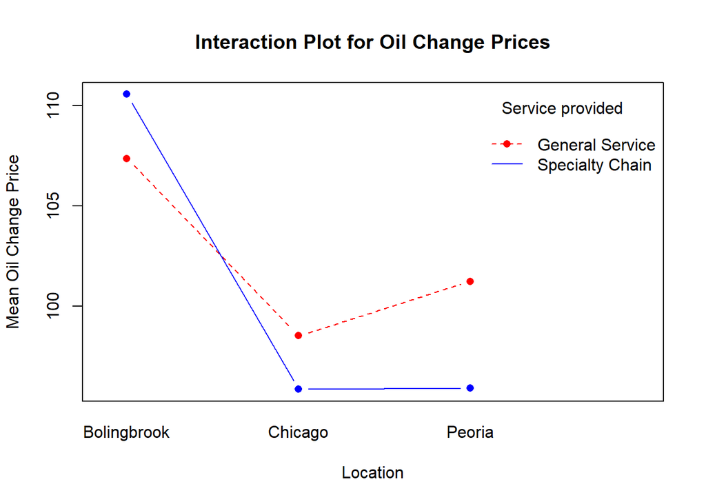

```r
# Interaction plot in R
interaction.plot(
  x.factor = meanOilChangePriceDataFrame$Location,       # Factor on x-axis
  trace.factor = meanOilChangePriceDataFrame$Service,  # Groups traced by color
  response = meanOilChangePriceDataFrame$Price,       # Response variable
  fun = mean,                            # Use means for each group
  type = "b",                            # Points and lines ("b" = both)
  col = c("red", "blue", "green"),       # Colors for Drug levels
  pch = 16,                              # Solid points
  xlab = "Location",
  ylab = "Mean Oil Change Price",
  trace.label = "Service provided",
  main = "Interaction Plot for Oil Change Prices"
)
```

### Interpretation of Interaction Plot

The plot shows that **there is an interaction but it is not statistically significant.**

This visually supports the **non-significant interaction term** (*p = 0.854*) found in the ANOVA table.

### Conclusion

- No significant **interaction** exists between Location and Service.
- **Service** does not significantly affects prices, regardless of location.
- **Location** alone does not significantly alter price levels.